# Validación cruzada y Superficies de respuesta

Maria Lucia Guastoni

25/2/2021

#### Introducción

Para un determinado estadístico de contraste se conoce su distribución asintótica (cuando el tamaño muestral tiende a infnito) pero de desconoce cual es su distribución para muestras pequeñas. El estadístico se utiliza dentro de un algoritmo que le pasa variables con tamaños muestrales diferentes y un nivel de significacíon prefijado. Por ello, son necesarios valores críticos para tamaños muestrales finitos, lo que podría llevar a la necesidad de tabular un volumen de tablas muy grande. Esto se puede evitar mediante la técnica conocida como superficies de respuesta.

Los datos del problema en cuestión se cargan a continuación, y también se realiza un gráfico de la distribución de los mismos:

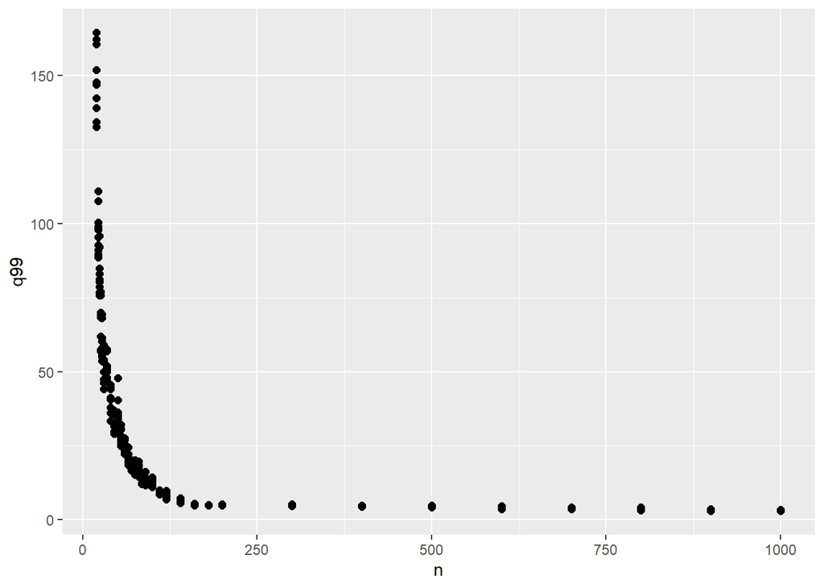

```r
df <- read.csv("CV_RS_quantils.csv", sep = ";")
ggplot(df, aes(x= n, y = q99)) +
  geom_point(size=2)
```

#### Preparación de los datos

Para poder aplicar la técnica anteriormente mencionada, es necesario, en primer lugar, realizar la transformación correspondiente de `n`, el tamaño muestral:

```r
df$x <- df$n^(-1/2)
```

#### Aplicación del modelo

Una vez realizada la transformación, es posible ajustar la función MCO para el quantil de interés, `q99`. Dado que no se conoce el grado del polinomio que mejor ajusta dicha regresión, se evaluará el error cuadrático medio (ECM) correspondiente a cada grado, desde 1 a 10, para luego seleccionar el grado que arroje un menor ECM.

Para realizar este procedimiento, se utilizarán dos técnicas de Cross - Validation: la primera con 10 folds (K = 10), y la segunda dejando una observación afuera (LOO).

El procedimiento es el siguiente:

##### CV con K = 10

```r
set.seed(1)
cv.error=rep(0,10)
degree=1:10
for(d in degree){
  glm.fit = glm(q99 ~ poly(x, d), data = df)
  cv.error[d] = cv.glm(df, glm.fit, K = 10)$delta[1]
}

cv.error
```

```
##  [1] 257.93730  72.21903  47.94495  27.99772  17.91736  16.20601  19.22153
##  [8]  17.58199  16.11194  15.58872
```

```r
min(cv.error)
```

```
## [1] 15.58872
```

```r
which.min(cv.error)
```

```
## [1] 10
```

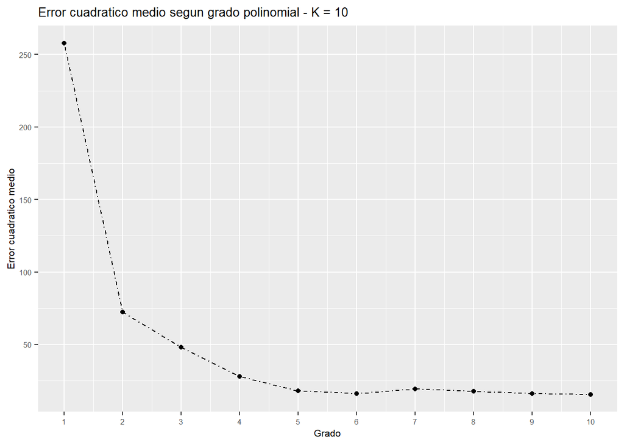

```r
aux <- data.frame(x=degree,y=cv.error)
ggplot(aux, aes(x,y)) +
  geom_point() +
  geom_line(linetype = "dotdash" ) +
  scale_x_continuous(breaks=seq(0,10,1)) +
  labs(x = "Grado",
       y = "Error cuadratico medio",
       title = "Error cuadratico medio segun grado polinomial - K = 10") +
  theme(plot.title = element_text(size=10),
        axis.text.x = element_text(size=6),
        axis.text.y = element_text(size=6),
        axis.title.x = element_text(size = 8),
        axis.title.y = element_text(size = 8))
```

Puede verse que el grado 10 es aquel que arroja un menor ECM, siendo de 15,59.

##### Leave One Out (LOO)

```r
set.seed(1)
cv.error_loo=rep(0,10)
for(d in degree){
  glm.fit = glm(q99 ~ poly(x, d), data = df)
  cv.error_loo[d] = cv.glm(df, glm.fit)$delta[1]
}
cv.error_loo
```

```
##  [1] 254.67451  69.01300  47.98619  28.90991  17.32005  16.28102  16.22832
##  [8]  16.26052  16.27471  15.92648
```

```r
min(cv.error_loo)
```

```
## [1] 15.92648
```

```r
which.min(cv.error_loo)
```

```
## [1] 10
```

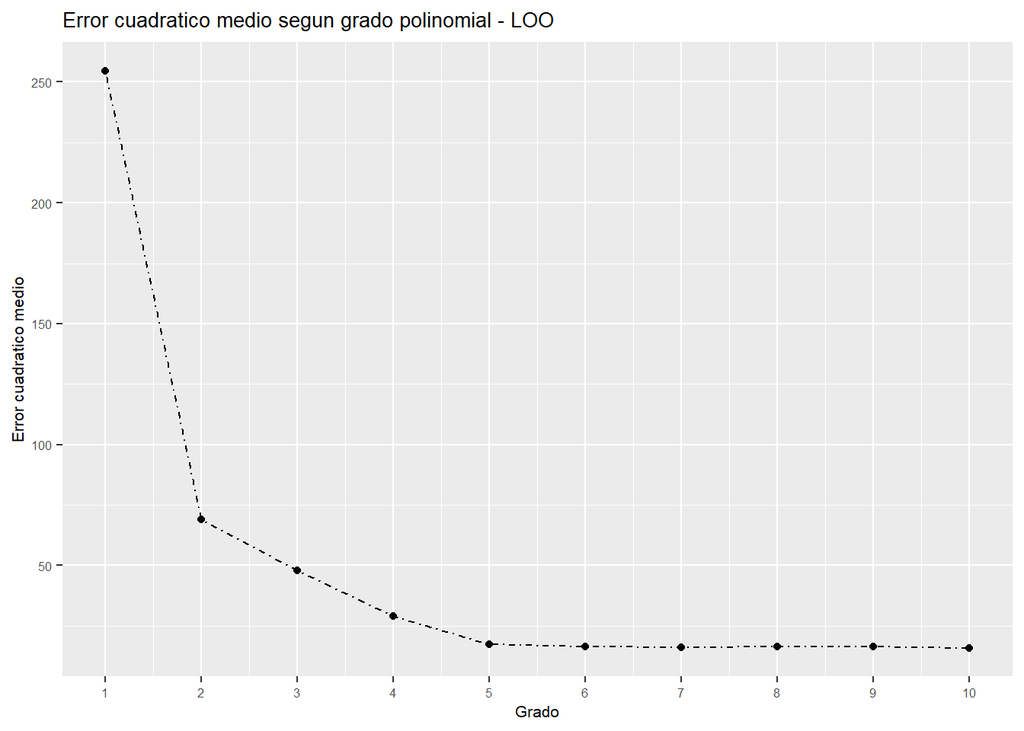

```r
aux <- data.frame(x=degree,y=cv.error_loo)
ggplot(aux, aes(x,y)) +
  geom_point() +
  geom_line(linetype = "dotdash" ) +
  scale_x_continuous(breaks=seq(0,10,1)) +
  labs(x = "Grado",
       y = "Error cuadratico medio",
       title = "Error cuadratico medio segun grado polinomial - LOO") +
  theme(plot.title = element_text(size=10),
        axis.text.x = element_text(size=6),
        axis.text.y = element_text(size=6),
        axis.title.x = element_text(size = 8),
        axis.title.y = element_text(size = 8))
```

Por lo tanto, el valor seleccionado de p es 10, siendo este el más adecuado.

Dado que las observaciones estan ordenadas de forma ascendente en función del tamaño muestral, el método de VC k - fold estará sesgado, puesto que el tamaño muestral promedio de cada fold irá aumentando a medida que se incremente el número de fold. Una posible solución es aplicar un shuffle a los datos antes de hacer la validación cruzada, para que las observaciones sean muestreadas aleatoriamente.